# Utilities for Handling Single-cell RNA-seq Data

# 3 Applied NESS across multiple GCP Values

To evaluate the stability and quality of SNE methods embeddings, we compute results across a range of GCP (global convergence parameter) values using NESS.

We first set a list of GCP values.

```r
GCP = c(1,5,10,15,20,30,40,50,100,200,300,500)
```

Then we call the NESS function, and it will return visual and numerical summaries to help evaluate embedding quality: • A scatter plot shows cells colored by how stable their neighborhood is across repeated runs, highlighting robust versus uncertain regions. • A line plot displays how overall embedding stability changes across different GCP values. • If cell type labels are provided, an additional plot shows the embedding colored by cell type for biological interpretation. • If rareness analysis is enabled, a summary plot visualizes how consistent neighborhood structures are across iterations, helping detect rare or transitional cell states.

```r
scale.data <- as.matrix(scale.data)
result <- NESS(
    GCP = GCP,
    data = scale.data,
    cell_type = cls,
    rareness = TRUE,
    data.name = "mouse_hema",
    method = "tsne",
    initialization = 1,
    stability_threshold = 0.75,
    early_stop = TRUE
)
```

```
## [1] "Index of median rareness score: 2"
## [1] "Corresponding GCP value for median rareness score: 5"
## [1] "The final GCP is 5 with a global stability of 0.997967032967033"
```

You can access and display these results directly:

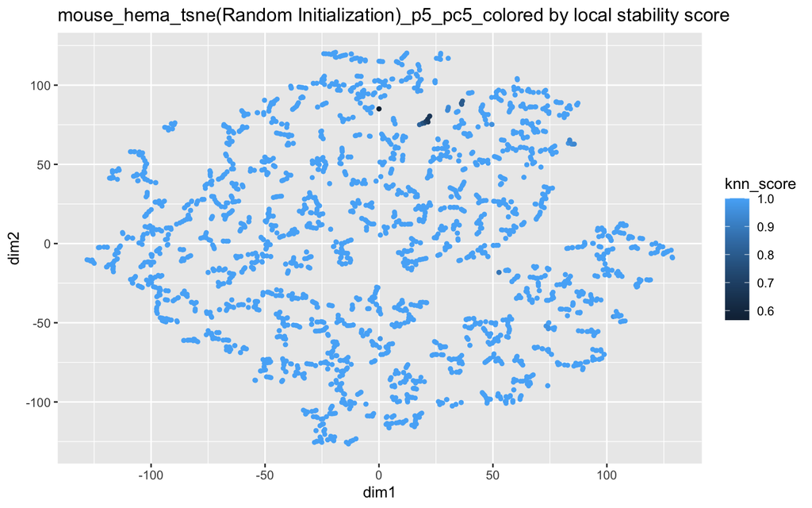

```r
# Scatter plot colored by local stability
result$plot_list_stability
```

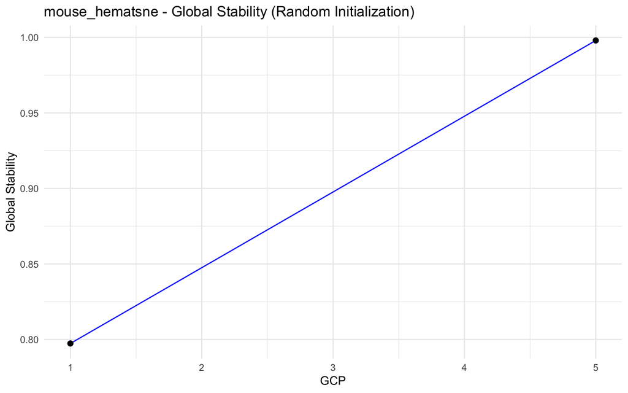

```r
# Global stability trend across GCP values
result$global_stability_plot
```

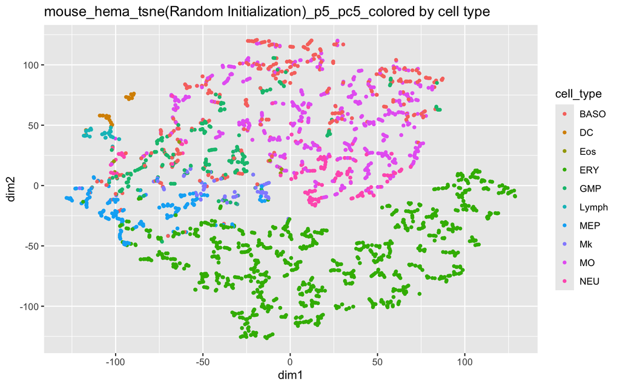

```r
# Embedding colored by cell type (if cell types were provided)
result$plot_list_cell_type
```

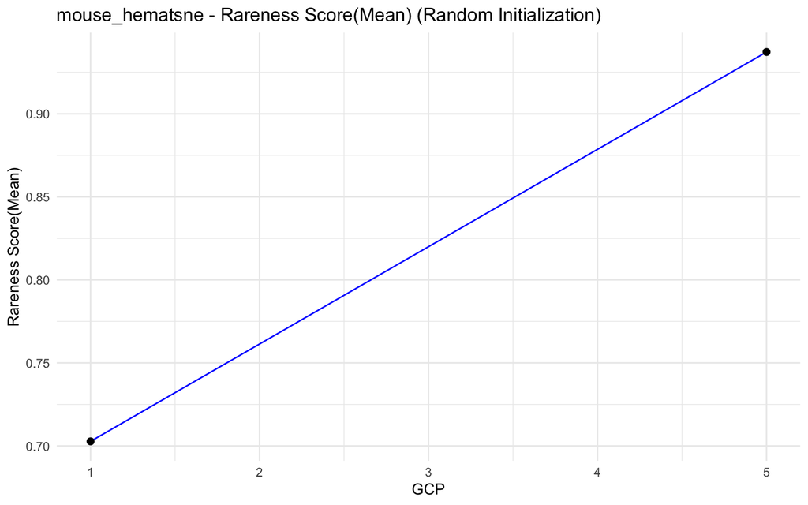

```r
# (Optional) Rareness score plot (if rareness = TRUE)
result$rareness_mean
```